# Final Project

Anthony Zhong

2025-12-07

Read in Data

```r
#Reads UN Sustainable Development 2023 Report
sdr_data <- read_csv("../data/SDR-2023-Data.csv")
#Cleans data column names
sdr_data <- sdr_data %>% clean_names()
```

### VISUALIZATION #1

```r
swb_histogram <- ggplot(sdr_data, aes(x = normalized_score_sdg3_swb, fill=regions_used_for_the_sdr)) +
  geom_histogram() +
  theme_minimal() +
  scale_fill_viridis_d() +
  labs(title = "Distributions of SDG 3 Score",
       x = "SDG 3 Score (Subjective Well Being)",
       y = "Number of Countries",
       fill = "Region")

ggplotly(swb_histogram)
```

[interactive chart not shown]

This visualization examines the frequency/count of nations’ normalized scores for subjective well-being, measured on a scale of 0 to 100. A score of 0 represents the lowest possible rating a nation could give their own subjective well-being, while 100 represents the highest. I chose to visualize this using a stacked histogram to display the global distribution of these scores and identify how different regions contribute to global trends. The color-coding by region helps reveal distinct geographic insights into where well-being may cluster around. For instance, the nations colored light green belong to the Organisation for Economic Co-operation and Development (OECD), which are generally high-income countries, and they all almost exclusively cluster near the high end of the well-being spectrum. Conversely, the yellow nations, representing the Sub-Saharan Africa region, cluster heavily near the bottom end of the spectrum. Meanwhile, nations in regions like the Middle East & North Africa (MENA), Eastern Europe & Central Asia, and Latin America & the Caribbean (LAC) are scattered more broadly across the middle of the spectrum. Notably, the largest concentration of countries appears to be centered around a score of 60-70. My next visualization will take these scores and plot them on a world map to better isolate specific country performance.

### VISUALIZATION #2

```
## [1] "spec_tbl_df" "tbl_df"      "tbl"         "data.frame"
```

```
## [1] "sf"          "spec_tbl_df" "tbl_df"      "tbl"         "data.frame"
```

```r
# mypal is my color palette function that maps data to the Spectral colors
mypal <- colorQuantile(palette = "Spectral", domain = sdr_data_world_joined$normalized_score_sdg3_swb, n = 5)

# Build the map
leaflet(sdr_data_world_joined) %>%
  addTiles() %>%
  setView(lat=0, lng=20, zoom=2) %>%
  addPolygons(
    stroke = FALSE,
    fillOpacity = 0.5,
    smoothFactor = 0.5,
    color = ~mypal(normalized_score_sdg3_swb),
    label = mytext
  ) %>%
  addLegend(
    pal = mypal,
    values = ~normalized_score_sdg3_swb,
    opacity = 0.7,
    title = "SDG 3 Score (Quantiles)",
    position = "bottomright"
  )
```

[interactive chart not shown]

In this map visualization, each country is colored according to its population’s normalized subjective well-being score. As the legend indicates, the deepest red represents the bottom 20% of scores, while the blue countries represent the top 20%. Interestingly, this map highlights distinct characteristics/clusters and other discrepancies that were not as visible in the stacked histogram. For instance, I did not expect India, located in the South Asia region, to have a normalized well-being score of only 13.95 out of 100. Meanwhile, OECD countries like South Korea and Japan fall into the same middle-tier quantile as Brazil and the Philippines, which is a surprising finding given their economic differences. Furthermore, it is striking to see how high the well-being scores of Saudi Arabia and the United Arab Emirates are compared to their immediate neighbors, who mostly score in the bottom two quantiles. Sadly, the continent of Africa clearly contains the world’s lowest well-being values. For instance, countries like Sudan, the Democratic Republic of Congo, and Egypt all score less than 20 out of 100.

Since we have established that some countries are surprisingly low (India) and some are surprisingly high (Saudi Arabia), a logical next step is to ask: “What actually drives these scores?”

### VISUALIZATION #3

```r
# Preparing for random forest machine learning where it predicts "normalized_score_sdg3_swb" using all other normalized scores
rf_data <- sdr_data %>%
  clean_names() %>%
  select(normalized_score_sdg3_swb, starts_with("normalized_score"))

# Random Forest fails if there are NAs, so crease rf_data_imputed with missRanger that fills NAs.
set.seed(123)
rf_data_imputed <- missRanger(rf_data)

rf_model <- randomForest(normalized_score_sdg3_swb ~ .,
                         data = rf_data_imputed,
                         importance = TRUE)

rf_model
```

[output not shown]

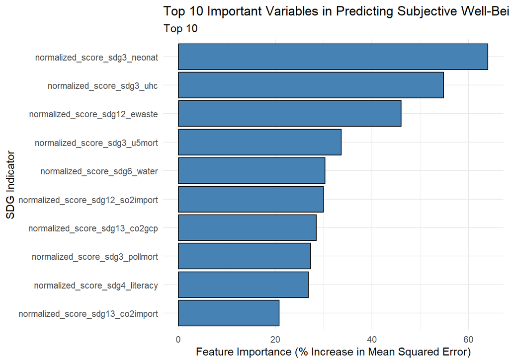

```r
# Convert the importance metrics into a dataframe for plotting
importance_df_top_10 <- as.data.frame(rf_model$importance) %>%
  rownames_to_column(var = "variable") %>%
  slice_max(n = 10, order_by = `%IncMSE`)

# Bar Plot
ggplot(importance_df_top_10, aes(x = `%IncMSE`, y = reorder(variable, `%IncMSE`))) +
  geom_bar(stat = "identity", fill = "steelblue", color = "black") +
  theme_minimal() +
  labs(title = "Top 10 Important Variables in Predicting Subjective Well-Being",
       subtitle = "Top 10",
       y = "SDG Indicator",
       x = "Feature Importance (% Increase in Mean Squared Error)")
```

According to this bar plot, we can identify the top 10 variables that are most important for predicting Subjective Well-Being. The x-axis measures importance using ‘% Increase in Mean Squared Error’. This tells us how much our model’s accuracy would suffer if we removed that specific variable.

### VISUALIZATION #4

```r
# Normalized scores Correlation Plot
correlation_plot <- ggplot(sdr_data, aes(x = normalized_score_sdg3_neonat,
                           y = normalized_score_sdg3_swb)) +
  geom_point() +
  geom_smooth() +
  stat_cor(output.type = "text") +
  theme_minimal() +
  labs(title="Correlation of Child Survival and Subjective Well-Being",
       x = "Score of Neonatal Mortality",
       y = "Score of Good Health and Well-Being"
       )

ggplotly(correlation_plot, tooltip = "label") # Added interactive plot function
```

[interactive chart not shown]

```r
# Normalized scores Correlation Plot
correlation_plot2 <- ggplot(sdr_data,
  aes(x = neonatal_mortality_rate_per_1_000_live_births,
      y = subjective_well_being_average_ladder_score_worst_0_10_best)) +
  geom_point() +
  geom_smooth() +
  stat_cor(output.type = "text") +
  theme_minimal() +
  labs(title="Correlation of Child Survival and Subjective Well-Being",
       x = "Score of Neonatal Mortality",
       y = "Score of Good Health and Well-Being"
       )

ggplotly(correlation_plot2, tooltip = "label") # Added interactive plot function
```

[interactive chart not shown]

For my final visualization, I plotted the both the normalized and non-normalized Subjective Well-Being score against the top predictor identified by the Random Forest model: Neonatal Mortality per 1,000. It is crucial to note that because these are ‘normalized scores,’ a higher value on the X-axis represents a better outcome (fewer deaths). Furthermore, we can see the flip-version when we used non-normalized scores instead.

Therefore, a score of 100 indicates the lowest possible mortality rate. The scatter plot reveals a very strong positive correlation (R = 0.75), indicated by the steep upward slope of the trend line. Countries in the bottom-left corner have both low survival scores (high mortality) and low well-being scores. Conversely, as we move to the top-right, we see that nations with the highest rates of child survival (scores near 100) also report the highest levels of happiness. This visually confirms the machine learning model’s finding: ensuring the survival of the youngest citizens is inextricably linked to the overall happiness of a nation.